# Multi-species functional responses

For feeding experiments with multiple prey species ($i=1,\dots,m$), feeding rates $F_i$ on a focal species $i$ are expected to decline in the presence of alternative prey $k$, see e.g. [Rosenbaum et al. (2024)](https://doi.org/10.1111/2041-210X.14372). We here use the multi-prey extension of the Holling type 2 functional response

$$F_i(N_1, \dots, N_m)=\frac{a_iN_i}{1+\sum_{k=1}^ma_kh_kN_k}$$
The BayesFR package is limited to 2-prey systems. Assuming eaten prey are not replaced during the feeding trial with initial prey densities $\left( \begin{smallmatrix} N_{1}(0)\\ N_{2}(0)\end{smallmatrix} \right)$, both prey densities $\left( \begin{smallmatrix} N_{1}(t)\\ N_{2}(t)\end{smallmatrix} \right)$ decline dynamically and interdependently in $t\in[0,T]$. We use the **coupled ODE system**

$$\begin{align}
\frac{dN_1}{dt}=-\frac{a_1N_1}{1+a_1h_1N_1+a_2h_2N_2}P \\
\frac{dN_2}{dt}=-\frac{a_2N_2}{1+a_1h_1N_1+a_2h_2N_2}P
\end{align}$$

with fixed predator density $P$, which is numerically integrated to compute prey densities at the end of the experiment $\left( \begin{smallmatrix} N_{1}(T)\\ N_{2}(T)\end{smallmatrix} \right)$. Predictions of eaten prey are then given by $\left( \begin{smallmatrix} N_{1}(0)-N_{1}(T)\\ N_{2}(0)-N_2(T)\end{smallmatrix} \right)$, which are fitted to observed numbers of eaten prey $\left( \begin{smallmatrix}N_{E1}\\ N_{E2}\end{smallmatrix} \right)$.

## Dataset

```r
library("BayesFR")
library("ggplot2")
library("cowplot")   # ggplot grids

df.all = df_Colton_1987_1_ECOLOGY
df.all$Time = df.all$Time/24 # convert units from hours to days
head(df.all)
```

```
  N01 N02 NE1 NE2 P0 Time
1   0  24   0   5  1    1
2   0  24   0   8  1    1
3   0  24   0  12  1    1
4   0  72   0  32  1    1
5   0  72   0  14  1    1
6   0  72   0  16  1    1
```

The experimental design (combinations of offered prey) is a full factorial grid, including single-prey experiments ($N_{01}=0$ or $N_{02}=0$) and multi-prey experiments ($N_{01},N_{02}>0$).

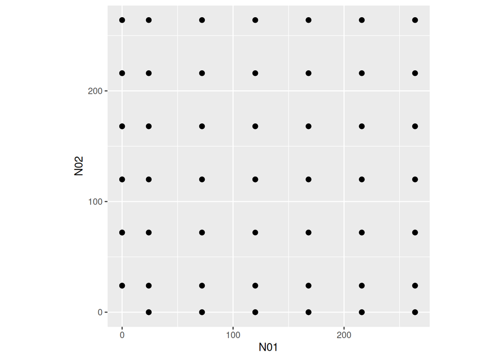

```r
ggplot(aes(N01,N02), data=df.all) +
  geom_point(size=2) +
  theme(aspect.ratio=1)
```

Plotting single-prey data only, **it looks like the predator consumes more of prey 1 than of prey 2.**

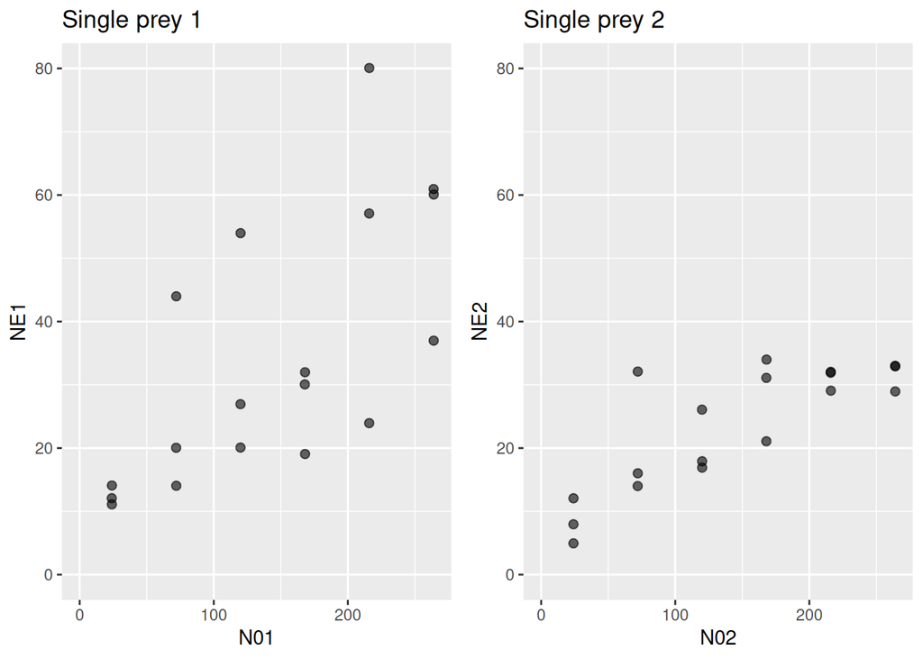

```r
df.1 = subset(df.all, N02==0)
p1 = ggplot(aes(N01,NE1), data=df.1) +
  geom_jitter(width=0.1, height=0.1, alpha=0.6, size=2) +
  coord_cartesian(xlim=c(0,NA), ylim=c(0,80)) +
  labs(title="Single prey 1")

df.2 = subset(df.all, N01==0)
p2 = ggplot(aes(N02,NE2), data=df.2) +
  geom_jitter(width=0.1, height=0.1, alpha=0.6, size=2) +
  coord_cartesian(xlim=c(0,NA), ylim=c(0,80)) +
  labs(title="Single prey 2")

plot_grid(p1,p2)
```

We can visualize multi-prey data by plotting the proportion of eaten prey $\frac{N_{E1}}{N_{E1}+N_{E2}}$ (y-axis) against the proportion of offered prey $\frac{N_{01}}{N_{01}+N_{02}}$ (x-axis) of prey species 1. Points below 1-1-line indicate prey species 1 is consumed relatively less often than available in environment. **In contrast to the single-prey data, the predator seems to have a preference for prey 2.**

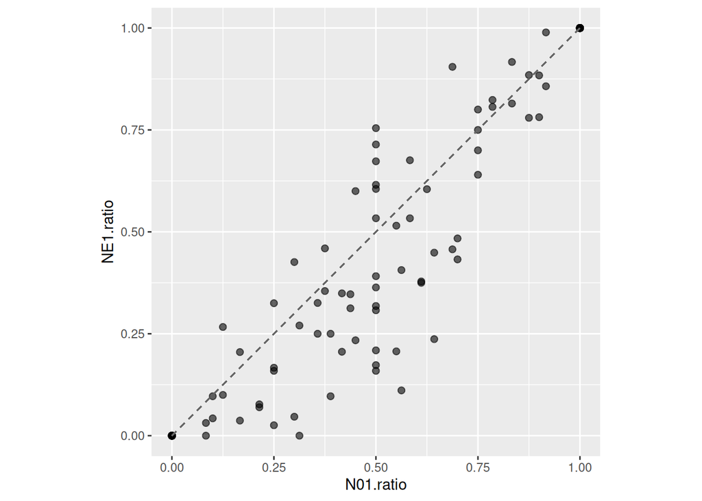

```r
df.all$N01.ratio = df.all$N01/(df.all$N01+df.all$N02)
df.all$NE1.ratio = df.all$NE1/(df.all$NE1+df.all$NE2)

ggplot(aes(N01.ratio,NE1.ratio), data=df.all)+
  geom_point(alpha=0.6, size=2) +
  coord_cartesian(xlim=c(0,1), ylim=c(0,1)) +
  theme(aspect.ratio=1) +
  geom_segment(x=0, y=0, xend=1, yend=1, color="grey40", linetype="dashed")
```

We will fit the Holling type 2 multi-species FR to the whole dataset (single- and multi-prey data) to investigate this phenomenon.

## Model fitting

First, the data needs to be converted from “wide” to “long” format with the function `convert_2sp_to_long`. Each row is split up in two rows with relevant columns

- `ID` focal prey ID (1 or 2)
- `NE` number of eaten prey of focal prey
- `N0` number of offered prey of focal prey
- `N0.alt` number of offered prey of alternative prey

This has purely technical reasons, since brms requires univariate model predictions. Predictions are still generated with the coupled ODE system, but with the “long” data format, predictions for each experiment are generated twice, once with output for `NE1` and once for `NE2`. Also, rows with `N0=0` are removed.

```r
df = convert_2sp_to_long(df.all)
str(df)
```

```
tibble [180 × 10] (S3: tbl_df/tbl/data.frame)
 $ N01      : int [1:180] 0 0 0 0 0 0 0 0 0 0 ...
 $ N02      : num [1:180] 24 24 24 72 72 72 120 120 120 168 ...
 $ P0       : num [1:180] 1 1 1 1 1 1 1 1 1 1 ...
 $ Time     : num [1:180] 1 1 1 1 1 1 1 1 1 1 ...
 $ N01.ratio: num [1:180] 0 0 0 0 0 0 0 0 0 0 ...
 $ NE1.ratio: num [1:180] 0 0 0 0 0 0 0 0 0 0 ...
 $ ID       : int [1:180] 2 2 2 2 2 2 2 2 2 2 ...
 $ NE       : int [1:180] 5 8 12 32 14 16 26 18 17 34 ...
 $ N0       : num [1:180] 24 24 24 72 72 72 120 120 120 168 ...
 $ N0.alt   : num [1:180] 0 0 0 0 0 0 0 0 0 0 ...
```

To fit the Holling type 2 MSFR, the function `MS_Type2H_dyn` is used for prediction, which takes data arguments `N0,N0.alt,ID,P0,Time` and parameters `a1,a2,h1,h2`. Choosing a Binomial distribution (and specifying the identity link) with `N0` trials, the prediction model is divided by `N0` to compute probability of being eaten, just as in the single-prey models.

```r
FR.formula = bf( NE|trials(N0) ~ MS_Type2H_dyn(N0,N0.alt,ID,P0,Time,a1,a2,h1,h2)/N0,
                 a1+a2+h1+h2 ~ 1,
                 nl = TRUE)

FR.priors  = c(prior(exponential(1), nlpar="a1", lb=0),
               prior(exponential(1), nlpar="a2", lb=0),
               prior(exponential(10), nlpar="h1", lb=0),
               prior(exponential(10), nlpar="h2", lb=0)
)

fit.1 = brm(FR.formula,
            family   = binomial(link="identity"),
            prior    = FR.priors,
            data     = df,
            cores    = 4,
            stanvars = stanvar(scode = MS_Type2H_dyn_code,
                               block = "functions")
            )
expose_functions(fit.1, vectorize = TRUE)
```

```r
summary(fit.1)
```

```
 Family: binomial
  Links: mu = identity
Formula: NE | trials(N0) ~ MS_Type2H_dyn(N0, N0.alt, ID, P0, Time, a1, a2, h1, h2)/N0
         a1 ~ 1
         a2 ~ 1
         h1 ~ 1
         h2 ~ 1
   Data: df (Number of observations: 180)
  Draws: 4 chains, each with iter = 2000; warmup = 1000; thin = 1;
         total post-warmup draws = 4000

Regression Coefficients:
             Estimate Est.Error l-95% CI u-95% CI Rhat Bulk_ESS Tail_ESS
a1_Intercept     0.63      0.06     0.52     0.75 1.01     1322     1466
a2_Intercept     0.91      0.08     0.76     1.10 1.00     1466     1289
h1_Intercept     0.01      0.00     0.01     0.02 1.00     1507     1905
h2_Intercept     0.03      0.00     0.02     0.03 1.00     2044     1955

Draws were sampled using sampling(NUTS). For each parameter, Bulk_ESS
and Tail_ESS are effective sample size measures, and Rhat is the potential
scale reduction factor on split chains (at convergence, Rhat = 1).
```

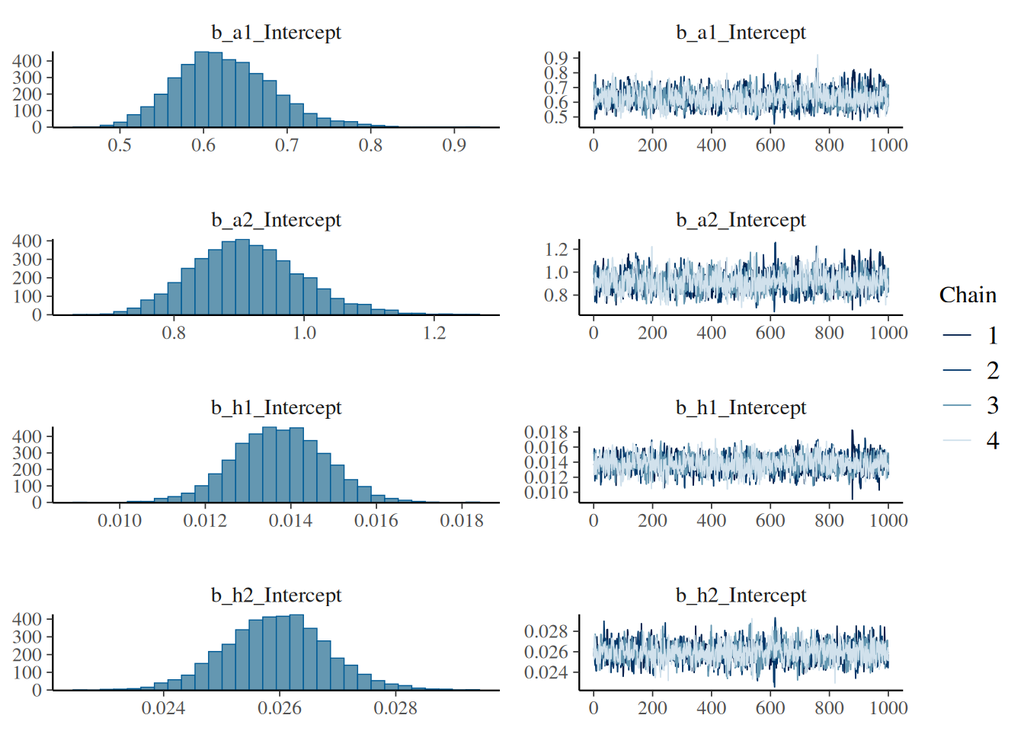

```r
plot(fit.1)
```

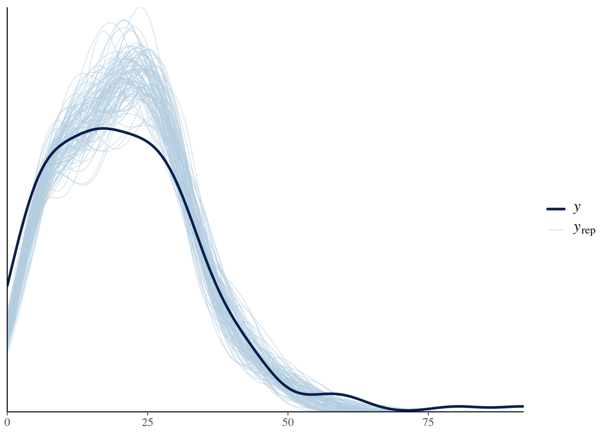

```r
plot(pp_check(fit.1, ndraws=100))
```

## Model investigation

Coming back to our **research question** (stronger feeding of prey 1 in single-prey experiments, but preference for prey 2 in multi-prey experiments), we check attack rates and handling times. Interestingly, $a_1<a_2$, which we verify by testing the posterior distribution of the difference:

```r
hypothesis(fit.1, "a1_Intercept < a2_Intercept")
```

```
Hypothesis Tests for class b:
                Hypothesis Estimate Est.Error CI.Lower CI.Upper Evid.Ratio
1 (a1_Intercept)-(a... < 0    -0.29      0.04    -0.36    -0.22        Inf
  Post.Prob Star
1         1    *
---
'CI': 90%-CI for one-sided and 95%-CI for two-sided hypotheses.
'*': For one-sided hypotheses, the posterior probability exceeds 95%;
for two-sided hypotheses, the value tested against lies outside the 95%-CI.
Posterior probabilities of point hypotheses assume equal prior probabilities.
```

```r
hypothesis(fit.1, "h1_Intercept < h2_Intercept")
```

```
Hypothesis Tests for class b:
                Hypothesis Estimate Est.Error CI.Lower CI.Upper Evid.Ratio
1 (h1_Intercept)-(h... < 0    -0.01         0    -0.01    -0.01        Inf
  Post.Prob Star
1         1    *
---
'CI': 90%-CI for one-sided and 95%-CI for two-sided hypotheses.
'*': For one-sided hypotheses, the posterior probability exceeds 95%;
for two-sided hypotheses, the value tested against lies outside the 95%-CI.
Posterior probabilities of point hypotheses assume equal prior probabilities.
```

```r
hypothesis(fit.1, "(1/h1_Intercept) > (1/h2_Intercept)")
```

```
Hypothesis Tests for class b:
                Hypothesis Estimate Est.Error CI.Lower CI.Upper Evid.Ratio
1 ((1/h1_Intercept)... > 0    34.62      5.95    25.72    44.94        Inf
  Post.Prob Star
1         1    *
---
'CI': 90%-CI for one-sided and 95%-CI for two-sided hypotheses.
'*': For one-sided hypotheses, the posterior probability exceeds 95%;
for two-sided hypotheses, the value tested against lies outside the 95%-CI.
Posterior probabilities of point hypotheses assume equal prior probabilities.
```

Plotting single-prey data against model predictions again shows how the difference in eaten prey is driven by higher maximum feeding rate on prey 1.

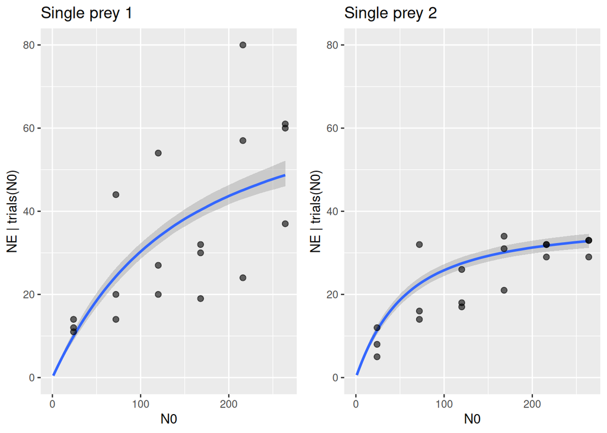

```r
p1 = plot(conditional_effects(fit.1,
                              conditions = data.frame(ID=1, N0.alt=0),
                              int_conditions = data.frame(N0=1:264),
                              effects="N0",
                              ndraws = 500),
          plot = FALSE)
df.plot = subset(df, ID==1 & N0.alt==0)
p1 = p1[[1]] + geom_point(data = df.plot,
                          aes(x=N0, y=NE),
                          inherit.aes = FALSE,
                          alpha=0.6, size=2) +
  coord_cartesian(xlim=c(0,NA), ylim=c(0,80)) +
  labs(title="Single prey 1")

p2 = plot(conditional_effects(fit.1,
                              conditions = data.frame(ID=2, N0.alt=0),
                              int_conditions = data.frame(N0=1:264),
                              effects="N0",
                              ndraws = 500),
          plot = FALSE)
df.plot = subset(df, ID==2 & N0.alt==0)
p2 = p2[[1]] + geom_point(data = df.plot,
                          aes(x=N0, y=NE),
                          inherit.aes = FALSE,
                          alpha=0.6, size=2) +
  coord_cartesian(xlim=c(0,NA), ylim=c(0,80)) +
  labs(title="Single prey 2")

plot_grid(p1,p2)
```

Plotting the whole dataset (single- and multi-prey feeding) shows, however, that feeding rate on prey 1 sharply declines in the presence of prey two (green and red curves in left figure), while feeding rate on prey 2 just weakly declines in the presence of prey 1 (right figure). This is driven by $a_2>a_1$.

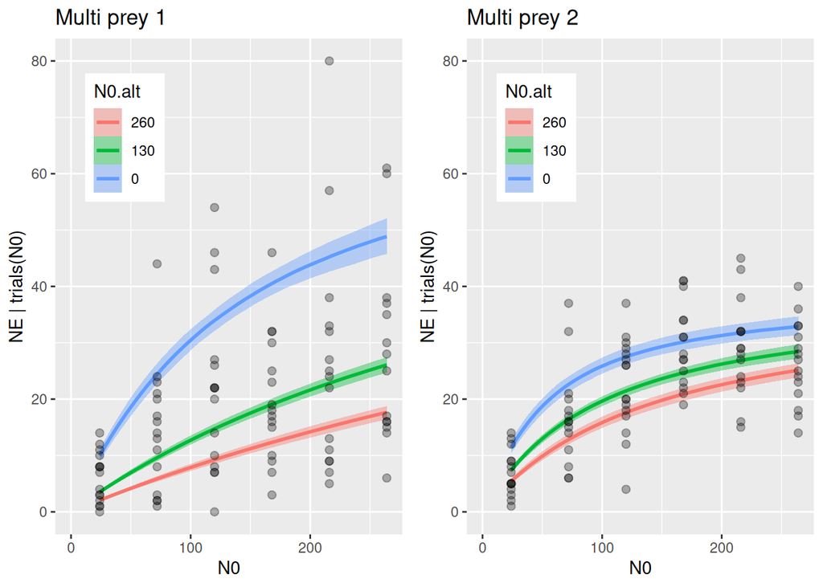

```r
p1 = plot(conditional_effects(fit.1,
                              conditions = data.frame(ID=1),
                              effects="N0:N0.alt",
                              int_conditions = data.frame(N0.alt=c(0,130,260)),
                              ndraws = 500),
          plot = FALSE)
df.plot = subset(df, ID==1)
p1 = p1[[1]] + geom_point(data = df.plot,
                          aes(x=N0, y=NE),
                          inherit.aes = FALSE,
                          alpha=0.3, size=2) +
  coord_cartesian(xlim=c(0,NA), ylim=c(0,80)) +
  labs(title="Multi prey 1") +
  theme(legend.position = c(0.2, 0.8))

p2 = plot(conditional_effects(fit.1,
                              conditions = data.frame(ID=2),
                              effects="N0:N0.alt",
                              int_conditions = data.frame(N0.alt=c(0,130,260)),
                              ndraws = 500),
          plot = FALSE)
df.plot = subset(df, ID==2)
p2 = p2[[1]] + geom_point(data = df.plot,
                          aes(x=N0, y=NE),
                          inherit.aes = FALSE,
                          alpha=0.3, size=2) +
  coord_cartesian(xlim=c(0,NA), ylim=c(0,80)) +
  labs(title="Multi prey 2") +
  theme(legend.position = c(0.2, 0.8))

plot_grid(p1,p2)
```

Realized preference (ratio of eaten prey vs ratio of offered prey) can be predicted as well. Posterior predictions for `NE1` and `NE2` are generated using `posterior_epred`, along a gradient of offered prey ratio (while keeping total number of offered prey constant), to compute posterior ratios of eaten prey.

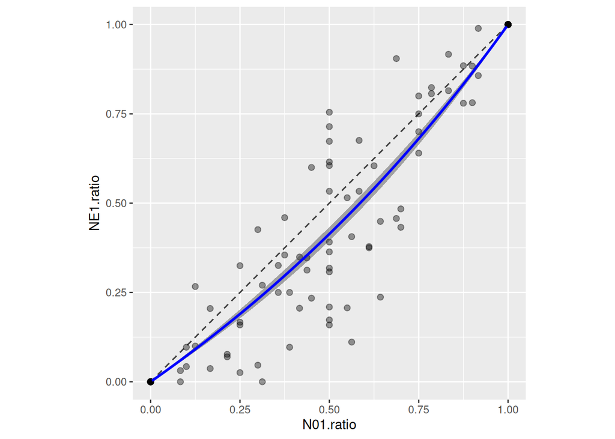

```r
# choose level of total prey abundance (constant)
N.total = 250
df.pred = data.frame(N01 = 1:(N.total-1),
                     N02 = (N.total-1):1)
df.pred$ratio = df.pred$N01/(df.pred$N01+df.pred$N02)

# set up dataframes for posterior predictions
df.pred.1 = data.frame(N0     = df.pred$N01,
                       N0.alt = df.pred$N02,
                       ID = 1, P0 = 1, Time = 1)
df.pred.2 = data.frame(N0     = df.pred$N02,
                       N0.alt = df.pred$N01,
                       ID = 2, P0 = 1, Time = 1)

# posterior predictions for prey1, prey2, and ratio
post.1 = posterior_epred(fit.1, newdata=df.pred.1)
post.2 = posterior_epred(fit.1, newdata=df.pred.2)
post.ratio = post.1/(post.1+post.2)

# posterior ratio means and credible intervals
df.pred$mean  = colMeans(post.ratio)
df.pred$upper = apply(post.ratio, 2, quantile, probs = 0.975)
df.pred$lower = apply(post.ratio, 2, quantile, probs = 0.025)

ggplot(df.all, aes(x=N01.ratio, y=NE1.ratio)) +
  geom_segment(x=0, y=0, xend=1, yend=1, color="grey30", linetype="dashed") +
  geom_point(alpha=0.4, size=2) +
  geom_ribbon(df.pred, mapping=aes(x=ratio, ymin=lower, ymax=upper),
              alpha = 0.4, inherit.aes=FALSE) +
  geom_line(df.pred, mapping=aes(x=ratio, y=mean),
              color = "blue", linewidth = 1, inherit.aes=FALSE) +
  theme(aspect.ratio = 1)
```

Here, a preference for prey 2 shows.